# Les étudiant(e)s d'informatiques face à la situation sanitaire

Ce notebook présentera rapidement les résultats d'un sondage mené parmis les étudiants d'informatique par l'association **IP7** .

Ce notebook a été réalisé par Marie Bétend.

## Questions du sondage

Voici les questions posées, certaines proviennent de [cette etude de l'IPSOS](https://www.ipsos.com/sites/default/files/ct/news/documents/2021-01/ipsos_rapport_fondamental_focus_jeunes_0.pdf) :

- Vous :
  - Vous êtes * :
    - Une femme
    - Un homme
    - Une personne non binaire
    - Autre
    - Ne souhaite pas répondre
  - En quelle année êtes vous ? *
    - L1
    - L2
    - L3
    - M1
    - M2
  - Dans quelle filière étudiez vous ? *
    - *Champs texte à remplir*
- Votre ressenti :
  - Vous sentez-vous épanoui(e) dans vos études ? * *1 correspondant à "Pas du tout" et 5 "Très fortement "*
    - 1
    - 2
    - 3
    - 4
    - 5
  - Avez-vous ressenti une baisse de motivation au cours de ces derniers mois ? *
    - Oui beaucoup
    - Oui un peu
    - Non
    - Ne souhaite pas répondre
  - Avez-vous ressenti l\'envie d\'arrêter vos études? *
    - Oui
    - Non
    - Ne souhaite pas répondre
  - Avez-vous consulté un(e) psychologue ou un(e) psychiatre suite à des difficultés liées à la situation sanitaire ? *
    - Oui
    - Non
    - Ne souhaite pas répondre
  - Si vous-même demain, étiez concerné(e) par l’apparition d’un trouble mental, et que vous ressentiez le besoin de consulter et d’être pris(e) en charge, sauriez-vous à qui vous adresser ? *
    - Oui, tout à fait
    - Oui, à peu près
    - Non, plutot pas
    - Non, pas du tout
    - Ne souhaite pas répondre
  - Vous sentez-vous isolé(e) socialement ? *
    - Oui beaucoup
    - Oui plutôt
    - Non pas trop
    - Non pas du tout
    - Ne souhaite pas répondre
  - Selon vous, le bien-être des étudiant(e)s est-il mis de côté ? *
    - Oui beaucoup
    - Oui plutôt
    - Non pas trop
    - Non pas du tout
    - Ne souhaite pas répondre
  - Troubles anxieux : *Dans le contexte de la Covid-19, à quelle fréquence avez-vous été gêné(e) par les problèmes suivants dans les deux dernières semaines ?*
    - Un sentiment de nervosité, d’anxiété ou de tension *

      ```
        * Jamais
        * Plusieurs jours
        * Plus de la moitié du temps
        * Presque tous les jours
        * Ne souhaite pas répondre
      ```

      - Une tendance à être facilement contrarié(e) ou irritable *

        ```
        * Jamais
        * Plusieurs jours
        * Plus de la moitié du temps
        * Presque tous les jours
        * Ne souhaite pas répondre
        ```

      - Des difficultés à se détendre *

        ```
        * Jamais
        * Plusieurs jours
        * Plus de la moitié du temps
        * Presque tous les jours
        * Ne souhaite pas répondre
        ```

      - Une inquiétude excessive à propos de différentes choses *

        ```
        * Jamais
        * Plusieurs jours
        * Plus de la moitié du temps
        * Presque tous les jours
        * Ne souhaite pas répondre
        ```

      - Une incapacité à arrêter de s’inquiéter ou à contrôler ses inquiétudes *

        ```
        * Jamais
        * Plusieurs jours
        * Plus de la moitié du temps
        * Presque tous les jours
        * Ne souhaite pas répondre
        ```

      - Une agitation telle qu’il est difficile de tenir en place *

        ```
        * Jamais
        * Plusieurs jours
        * Plus de la moitié du temps
        * Presque tous les jours
        * Ne souhaite pas répondre
        ```

      - Un sentiment de peur comme si quelque chose de terrible risquait de se produire *

        ```
        * Jamais
        * Plusieurs jours
        * Plus de la moitié du temps
        * Presque tous les jours
        * Ne souhaite pas répondre
        ```

  - Troubles dépréssifs : *Dans le contexte de la Covid-19, à quelle fréquence avez-vous été gêné(e) par les problèmes suivants dans les deux dernières semaines ?*
    - Vous sentir fatigué(e) ou avoir peu d’énergie *

      ```
        * Jamais
        * Plusieurs jours
        * Plus de la moitié du temps
        * Presque tous les jours
        * Ne souhaite pas répondre
      ```

    - Difficultés à vous endormir, à rester endormi ou trop dormir *

      ```
        * Jamais
        * Plusieurs jours
        * Plus de la moitié du temps
        * Presque tous les jours
        * Ne souhaite pas répondre
      ```

    - Vous sentir triste, déprimé(e) ou désespéré(e) *

      ```
        * Jamais
        * Plusieurs jours
        * Plus de la moitié du temps
        * Presque tous les jours
        * Ne souhaite pas répondre
      ```

    - Avoir peu d\'appétit ou trop d\'appétit *

      ```
        * Jamais
        * Plusieurs jours
        * Plus de la moitié du temps
        * Presque tous les jours
        * Ne souhaite pas répondre
      ```

    - Peu d\'intérêt ou de plaisir à faire les choses *

      ```
        * Jamais
        * Plusieurs jours
        * Plus de la moitié du temps
        * Presque tous les jours
        * Ne souhaite pas répondre
      ```

    - Mauvaise perception de vous-même, vous pensez que vous êtes un(e) perdant(e) ou que vous n\'avez pas satisfait vos propres attentes ou celles de votre famille *

      ```
        * Jamais
        * Plusieurs jours
        * Plus de la moitié du temps
        * Presque tous les jours
        * Ne souhaite pas répondre
      ```

    - Difficultés à vous concentrer sur des choses telles que lire le journal ou regarder la télévision *

      ```
        * Jamais
        * Plusieurs jours
        * Plus de la moitié du temps
        * Presque tous les jours
        * Ne souhaite pas répondre
      ```

      - Vous bougez ou vous parlez si lentement que les autres personnes ont pu le remarquer. Ou, au contraire, vous êtes si agité(e) que vous bougez beaucoup plus que d\'habitude *

        ```
        * Jamais
        * Plusieurs jours
        * Plus de la moitié du temps
        * Presque tous les jours
        * Ne souhaite pas répondre
        ```

      - Vous avez pensé que vous seriez mieux mort(e) ou vous avez pensé à vous blesser d\'une façon ou d\'une autre *

        ```
        * Jamais
        * Plusieurs jours
        * Plus de la moitié du temps
        * Presque tous les jours
        * Ne souhaite pas répondre
        ```

- Retour du présentiel
  - Considérez-vous que les modalités d’enseignement actuelles permettent une formation correcte ? *
    - Oui beaucoup
    - Oui plutôt
    - Non pas trop
    - Non pas du tout
    - Ne souhaite pas répondre
  - Des remarques par rapport aux méthodes d\'enseignement actuelles ?
    - *Zone texte à remplir*
  - Des pistes pour l\'amélioration des méthodes d\'enseignement ?
    - *Zone de texte à remplir*
  - Etes-vous favorable à une réouverture des facultés et des amphithéâtres ? *
    - Oui pour la totalité des cours
    - Oui en hybride, possibilité d\'aller en cours physiquement ou de le suivre à distance
    - Non
    - Ne souhaite pas répondre
  - Si les facs réouvraient 1 jour par semaine, seriez-vous en mesure de vous rendre en cours en présentiel ? * *Emmanuel Macron ayant annoncé "Un étudiant doit avoir les mêmes droits qu\'un salarié (...) S\'il en a besoin, il doit pouvoir revenir à l\'université un jour par semaine", seriez vous favorable à cette mesure, et pourriez vous vous rendre en cours en présentiel ?*
    - Oui
    - Non
    - Ne sait pas encore
    - Ne souhaite pas répondre
- Précarité
  - Avez-vous dû changer de logement à cause de la situation sanitaire ? *
    - Oui plusieurs fois
    - Oui une fois
    - Non
    - Ne souhaite pas répondre
  - Vous pouvez nous écrire un témoignage concernant votre logement ici
    - *Zone de texte à remplir*
  - Avez-vous bénéficié d\'une aide alimentaire avant le premier confinement ? *
    - Oui
    - Non
    - Ne souhaites pas répondre
  - Avez-vous eu besoin d\'une aide alimentaire depuis le début de la crise sanitaire ? *
    - Oui
    - Non
    - Ne souhaite pas répondre
- Mot de la fin
  - Si vous souhaitez nous laisser un petit mot ou témoigner de votre situation pour que l\'on puisse le remonter aux enseignant(e)s, c\'est ici :
    - *Zone de texte à remplir*

## Récupération des résultats et premiers traitements

```python
import warnings
warnings.filterwarnings('ignore')
```

```python
import numpy as np
import pandas as pd
import seaborn as sns

tmp = range(45)
data = pd.read_csv('etu.tsv', delimiter = '\t', header = 2, usecols = tmp[-36:])
```

```python
def to_category(df, labels):
    """
    df is a DataFrame
    labels is a list of strings
    """
    for e in labels:
        df[e] = df[e].astype('category')
```

```python
lab = ["Vous êtes ",
       "En quelle année êtes-vous ?",
       "Vous sentez-vous épanoui(e) dans vos études ?",
       "Avez-vous ressenti une baisse de motivation au cours de ces derniers mois ?",
       "Avez-vous ressenti l'envie d'arrêter vos études? ",
       "Avez-vous consulté un(e) psychologue ou un(e) psychiatre suite à des difficultés liées à la situation sanitaire ?",
       "Si vous-même demain, étiez concerné(e) par l’apparition d’un trouble mental, et que vous ressentiez le besoin de consulter et d’être pris(e) en charge, sauriez-vous à qui vous adresser ?",
       "Vous sentez-vous isolé(e) socialement ?",
       "Selon vous, le bien-être des étudiant(e)s est-il mis de côté ? ",
       "Un sentiment de nervosité, d’anxiété ou de tension",
       "Une tendance à être facilement contrarié(e) ou irritable",
       "Des difficultés à se détendre",
       "Une inquiétude excessive à propos de différentes choses",
       "Une incapacité à arrêter de s’inquiéter ou à contrôler ses inquiétudes",
       "Une agitation telle qu’il est difficile de tenir en place",
       "Un sentiment de peur comme si quelque chose de terrible risquait de se produire",
       "Vous sentir fatigué(e) ou avoir peu d’énergie ",
       "Difficultés à vous endormir, à rester endormi ou trop dormir",
       "Vous sentir triste, déprimé(e) ou désespéré(e)",
       "Avoir peu d'appétit ou trop d'appétit",
       "Peu d'intérêt ou de plaisir à faire les choses",
       "Mauvaise perception de vous-même, vous pensez que vous êtes un(e) perdant(e) ou que vous n'avez pas satisfait vos propres attentes ou celles de votre famille",
       "Difficultés à vous concentrer sur des choses telles que lire le journal ou regarder la télévision",
       "Vous bougez ou vous parlez si lentement que les autres personnes ont pu le remarquer. Ou, au contraire, vous êtes si agité(e) que vous bougez beaucoup plus que d'habitude",
       "Vous avez pensé que vous seriez mieux mort(e) ou vous avez pensé à vous blesser d'une façon ou d'une autre",
       "Considérez-vous que les modalités d’enseignement actuelles permettent une formation correcte ?",
       "Etes-vous favorable à une réouverture des facultés et des amphithéâtres ?",
       "Si les facs réouvraient 1 jour par semaine, seriez-vous en mesure de vous rendre en cours en présentiel ? ",
       "Avez-vous dû changer de logement à cause de la situation sanitaire ?",
       "Avez-vous bénéficié d'une aide alimentaire avant le premier confinement ?",
       "Avez-vous eu besoin d'une aide alimentaire depuis le début de la crise sanitaire ?"]
to_category(data, lab)
```

## Résultats globaux

```python
def perc_hue(plot, feature, hue):
    numCat = data[feature].nunique()
    numHue = data[hue].nunique()
    patch = [p for p in plot.ax.patches]

    a = [p.get_height() for p in patch]

    for i in range(numCat):
        total = data[feature].value_counts(sort=False).values[i]
        for j in range(numHue):
            percentage = '{:.1f}%'.format(100 * a[(j*numCat + i)]/total)
            x = patch[(j*numCat + i)].get_x() + patch[(j*numCat + i)].get_width() / 2 - 0.08
            y = patch[(j*numCat + i)].get_y() + patch[(j*numCat + i)].get_height() /2
            plot.ax.annotate(percentage, (x, y), size = 12, color='black')

def perc_no_hue(plot, feature):
    total = len(data[i])
    for p in plot.ax.patches:
        percentage = '{:.1f}%'.format(100 * p.get_height()/total)
        x = p.get_x() + p.get_width() /2 - 0.08
        y = p.get_y() + p.get_height()/2
        plot.ax.annotate(percentage, (x, y), color='black')
```

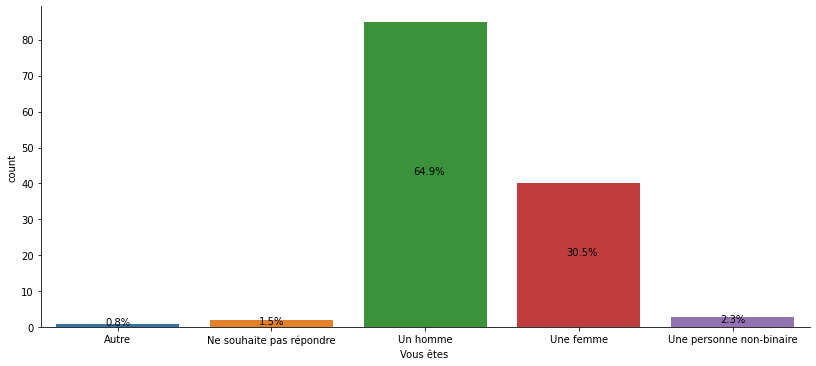

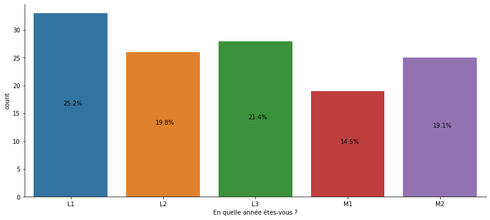

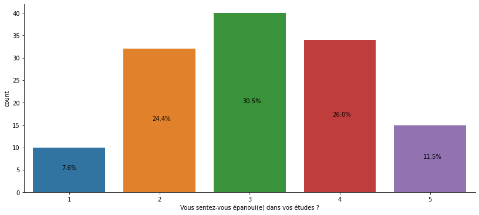

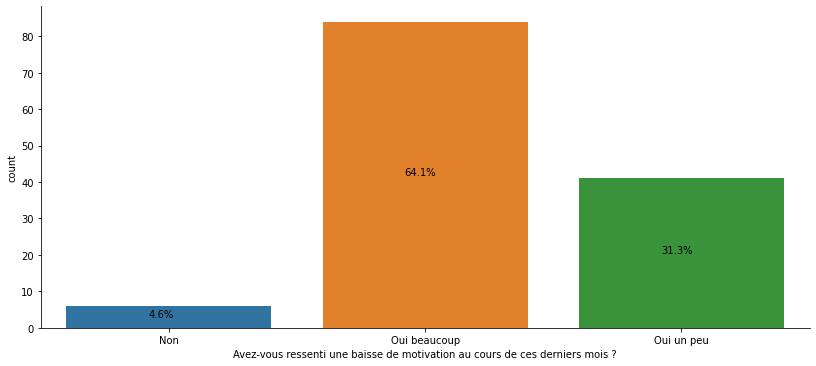

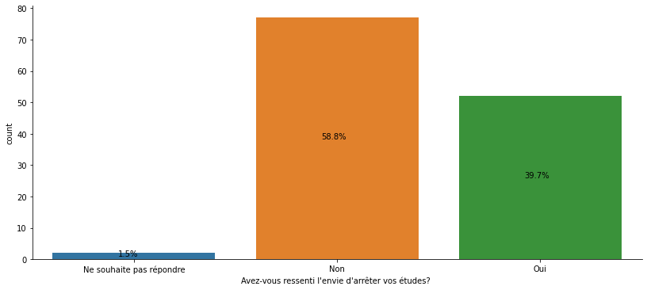

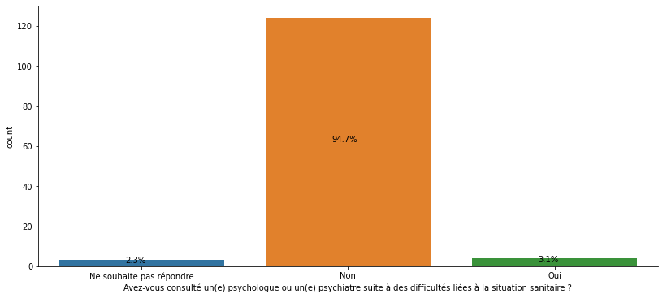

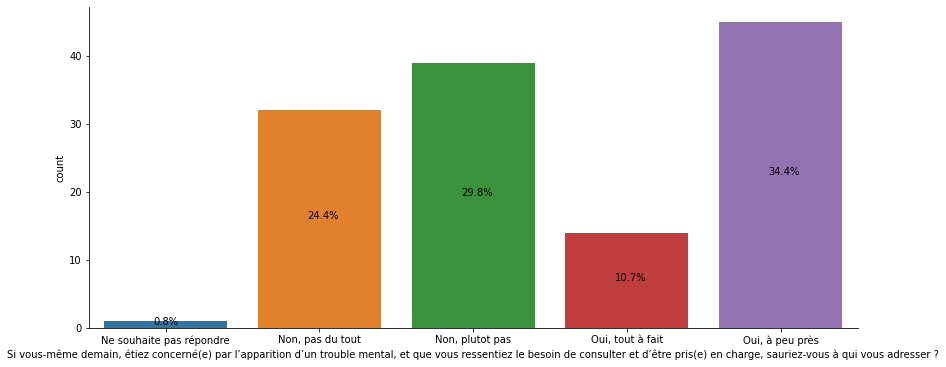

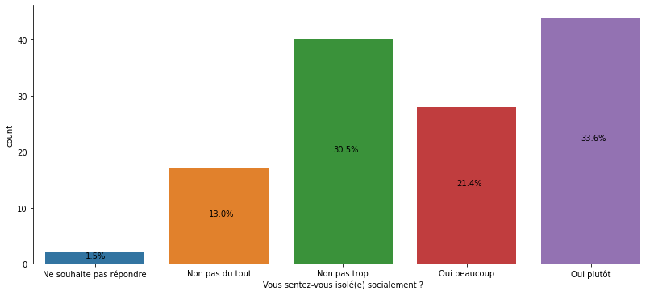

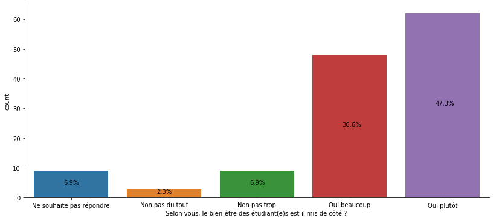

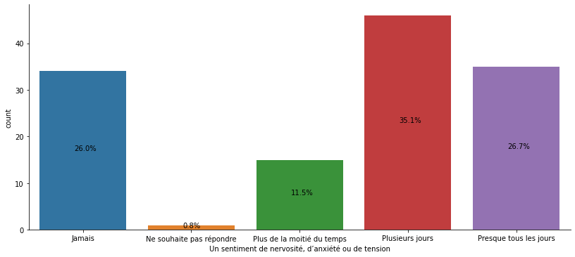

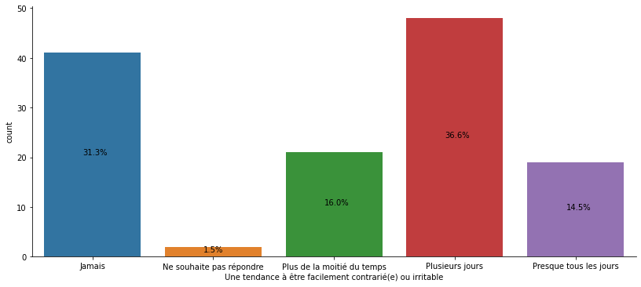

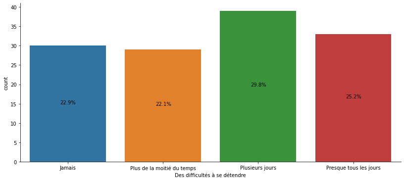

[19 more figures not shown]

```python
for i in lab :
    plot = sns.catplot(x=i, kind="count", data=data, aspect=18/8)
    perc_no_hue(plot,i)
```

### Résultats en distinguant l'année en cours

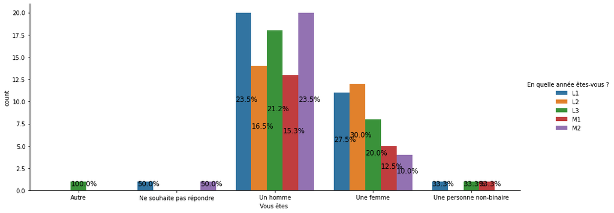

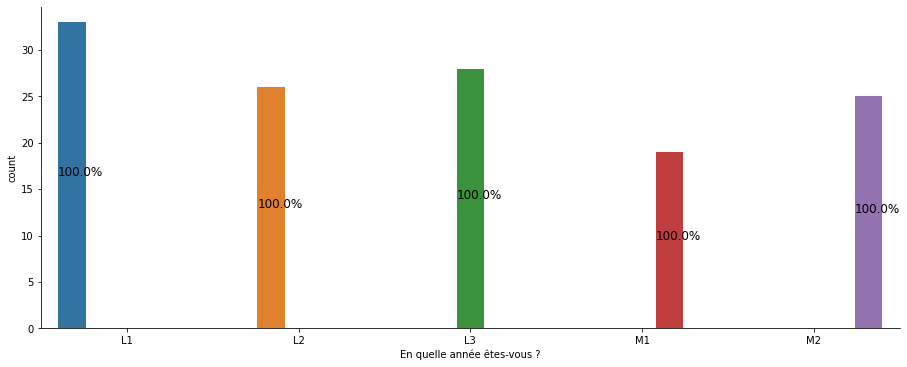

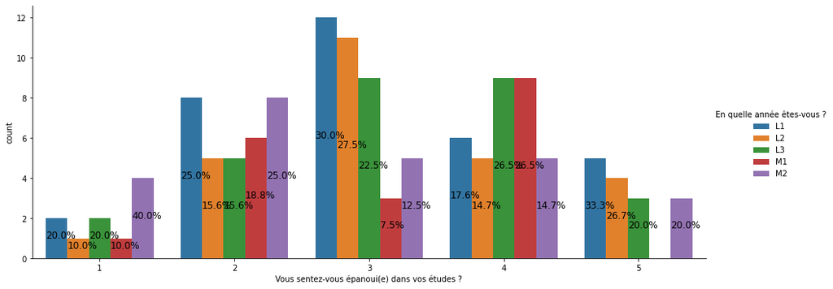

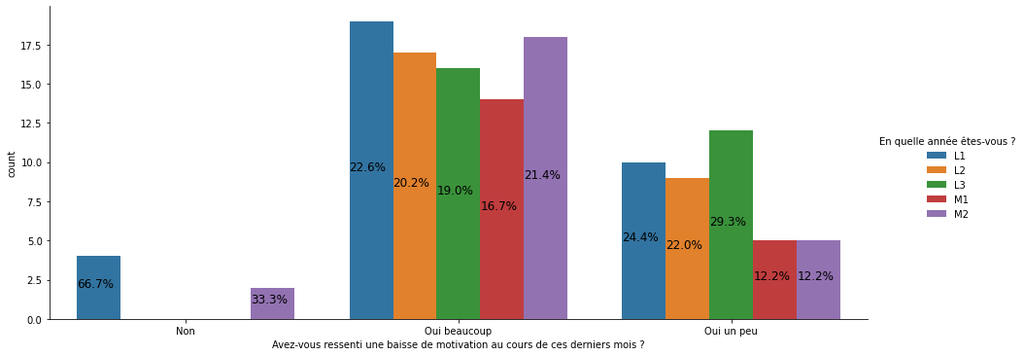

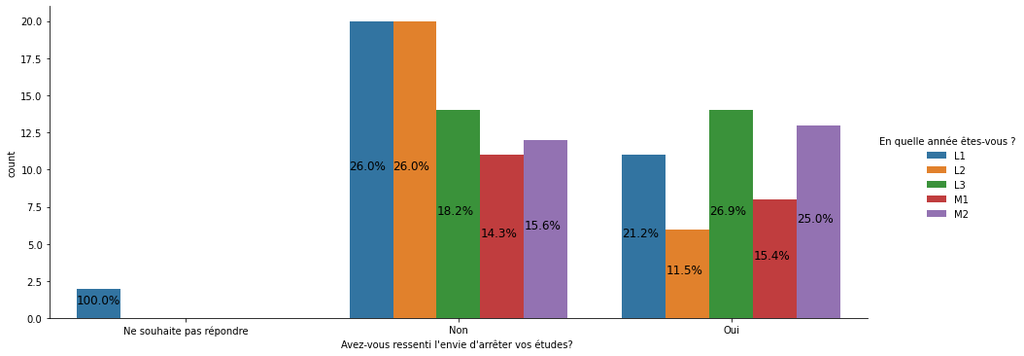

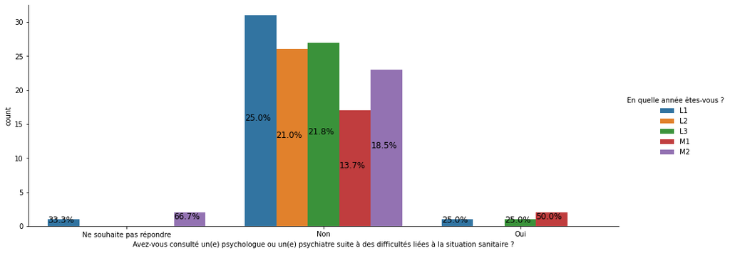

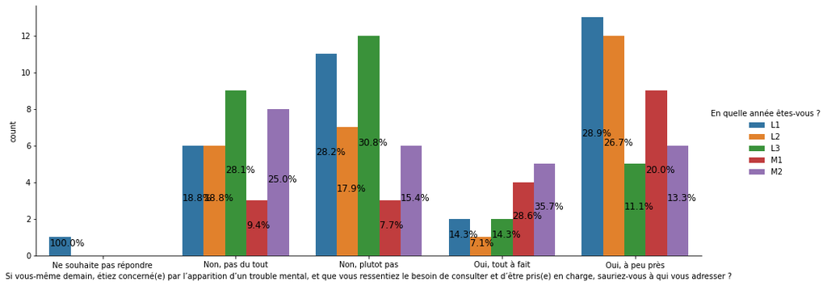

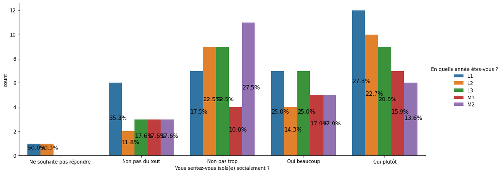

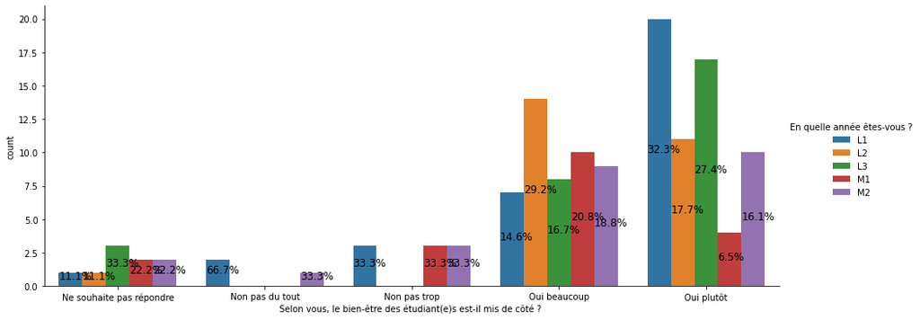

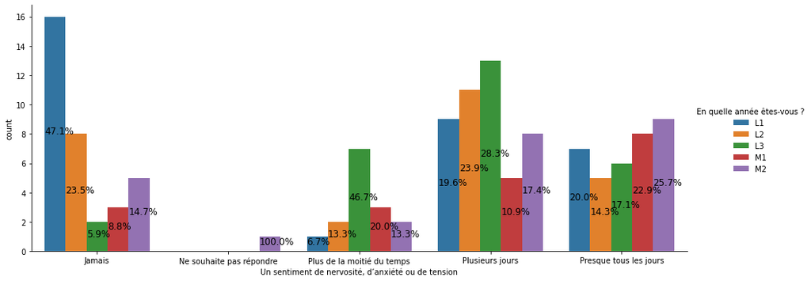

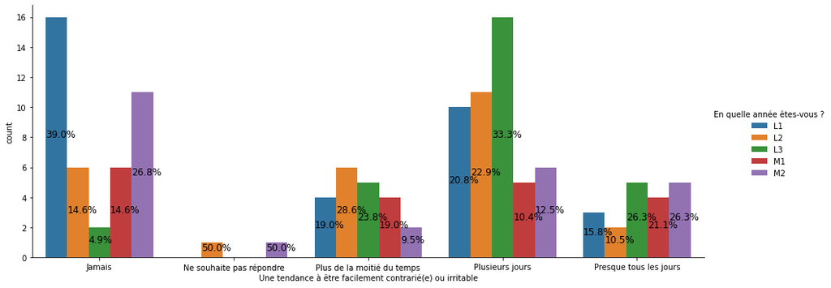

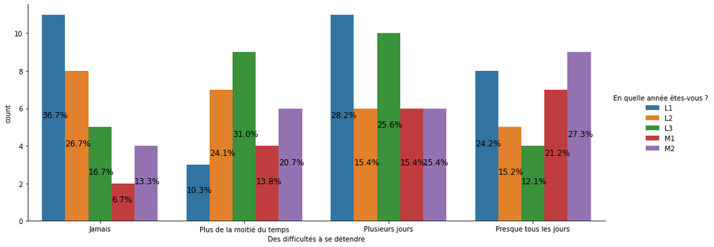

[19 more figures not shown]

```python
for i in lab :
    plot = sns.catplot(x=i, kind="count", hue="En quelle année êtes-vous ?", data=data, aspect=20/8)
    perc_hue(plot, i, "En quelle année êtes-vous ?" )
```